# Module used in this project

## hierarchical

### clustering process

```python
agglomer_model5 = AgglomerativeClustering(n_clusters = 2)
agglomer_model5.fit(df_sub5.iloc[:,:-1])
df_sub5['agglomer'] = agglomer_model5.labels_
```

### mapping process

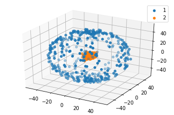

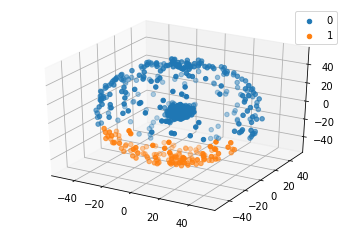

```python
group_sub5 = df_sub5.groupby(by = 'Class')
group_sub5_agglomer = df_sub5.groupby(by = 'agglomer')

fig = plt.figure()
ax_sub_origin = plt.axes(projection = '3d')
for (ele_id,ele) in group_sub5:
  ax_sub_origin.scatter3D(ele['X1'], ele['X2'],ele['X3'],label = ele_id)
plt.legend()


fig2 = plt.figure()
ax_sub_clustering = plt.axes(projection = '3d')
for (ele_id,ele) in group_sub5_agglomer:
  ax_sub_clustering.scatter(ele['X1'], ele['X2'], ele['X3'],label = ele_id)
plt.legend()

plt.show()
```

**According to the map we get manually, the matching relationship is a litter bit complex than question 1,3&4!!!!!!!**

```python
mapdict = {0:2,1:1}
df_sub5['agglomer_relabel'] = df_sub5['agglomer'].map(mapdict)
```

### external validation

```python
print('F1 score of this clustering model is:')
metrics.f1_score(df_sub5['Class'],df_sub5['agglomer_relabel'], average = 'weighted')
```

```
F1 score of this clustering model is:
```

```
0.6119832048204714
```

```python
print('Accuracy of this clustering model is:')
metrics.accuracy_score(df_sub5['Class'],df_sub5['agglomer_relabel'])
```

```
Accuracy of this clustering model is:
```

```
0.6575
```

### data visualization

**final plot**

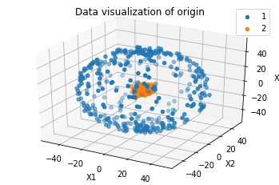

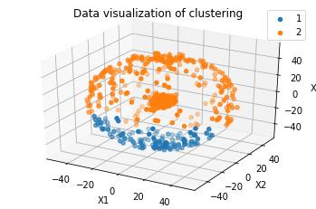

```python
group_sub5 = df_sub5.groupby(by = 'Class')
group_sub5_agglomer = df_sub5.groupby(by = 'agglomer_relabel')

fig = plt.figure()
ax_sub_origin = plt.axes(projection = '3d')
for (ele_id,ele) in group_sub5:
  ax_sub_origin.scatter3D(ele['X1'], ele['X2'],ele['X3'],label = ele_id)
ax_sub_origin.set_title('Data visualization of origin')
ax_sub_origin.set_xlabel('X1')
ax_sub_origin.set_ylabel('X2')
ax_sub_origin.set_zlabel('X3')
plt.legend()


fig2 = plt.figure()
ax_sub_clustering = plt.axes(projection = '3d')
for (ele_id,ele) in group_sub5_agglomer:
  ax_sub_clustering.scatter(ele['X1'], ele['X2'], ele['X3'],label = ele_id)
ax_sub_clustering.set_title('Data visualization of clustering')
ax_sub_clustering.set_xlabel('X1')
ax_sub_clustering.set_ylabel('X2')
ax_sub_clustering.set_zlabel('X3')
plt.legend()

plt.show()
```

# Dealing with Data6

## uploading the data

```python
from google.colab import files
files.upload()
df_sub6 = pd.read_csv(r'Data6.csv').iloc[:,1:]
```

Upload widget is only available when the cell has been executed in the current browser session. Please rerun this cell to enable.

```
Saving Data6.csv to Data6.csv
```

## exploring the data

```python
df_sub6.shape
```

```
(4096, 3)
```

```python
df_sub6.head(2)
```

|  | X1 | X2 | Class |
| --- | --- | --- | --- |
| 0 | 1.388261 | 2.076096 | 1 |
| 1 | 2.177247 | 3.102304 | 1 |

```python
df_sub6['Class'].value_counts()
```

```
1    2048
2    2048
Name: Class, dtype: int64
```

1. k = 2

## kmeans

### clustering process

```python
kmeans_model6 = KMeans(n_clusters = 2, random_state=1314520)
kmeans_model6.fit(df_sub6.iloc[:,:-1])
df_sub6['kmeans'] = kmeans_model6.labels_
```

### mapping process

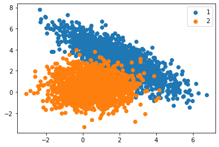

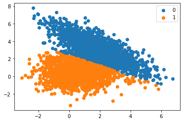

```python
group_sub6 = df_sub6.groupby(by = 'Class')
group_sub6_kmeans = df_sub6.groupby(by = 'kmeans')

fig = plt.figure()
ax_sub_origin = plt.axes()
for (ele_id,ele) in group_sub6:
  ax_sub_origin.scatter(ele['X1'], ele['X2'], label = ele_id)
plt.legend()

fig2 = plt.figure()
ax_sub_clustering = plt.axes()
for (ele_id,ele) in group_sub6_kmeans:
  ax_sub_clustering.scatter(ele['X1'],ele['X2'], label = ele_id)
plt.legend()

plt.show()
```

**According to the map we get manually, we can calculate acc and F1 now!**

```python
mapdict = {0:1,1:2}
df_sub6['kmeans_relabel'] = df_sub6['kmeans'].map(mapdict)
```

### external validation

```python
print('F1 score of this clustering model is:')
metrics.f1_score(df_sub6['Class'],df_sub6['kmeans_relabel'], average = 'weighted')
```

```
F1 score of this clustering model is:
```

```
0.9513828386139447
```

```python
print('accuracy of this clustering model is:')
metrics.accuracy_score(df_sub6['Class'],df_sub6['kmeans_relabel'])
```

```
accuracy of this clustering model is:
```

```
0.951416015625
```

### Data visualization

**final plot**

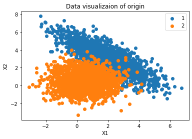

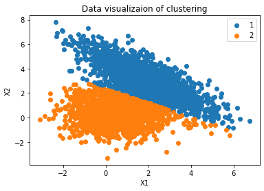

```python
group_sub6 = df_sub6.groupby(by = 'Class')
group_sub6_kmeans = df_sub6.groupby(by = 'kmeans_relabel')

fig = plt.figure()
ax_sub_origin = plt.axes()
for (ele_id,ele) in group_sub6:
  ax_sub_origin.scatter(ele['X1'], ele['X2'], label = ele_id)
ax_sub_origin.set(title = 'Data visualizaion of origin',xlabel = 'X1',ylabel= 'X2')
plt.legend()

fig2 = plt.figure()
ax_sub_clustering = plt.axes()
for (ele_id,ele) in group_sub6_kmeans:
  ax_sub_clustering.scatter(ele['X1'],ele['X2'], label = ele_id)
ax_sub_clustering.set(title = 'Data visualizaion of clustering',xlabel = 'X1',ylabel= 'X2')
plt.legend()

plt.show()
```

## hierarchical

### clustering process

**The output label of agglomerative Clustering changed every time you run the code. Please don't run this cell again**

```python
agglomer_model6 = AgglomerativeClustering(n_clusters = 2)
agglomer_model6.fit(df_sub6.iloc[:,:-1])
df_sub6['agglomer'] = agglomer_model6.labels_
```

### mapping process

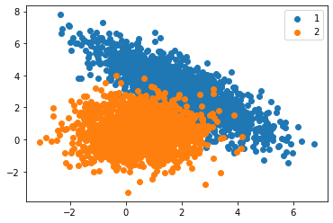

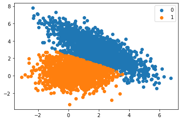

```python
group_sub6 = df_sub6.groupby(by = 'Class')
group_sub6_agglomer = df_sub6.groupby(by = 'agglomer')

fig = plt.figure()
ax_sub_origin = plt.axes()
for (ele_id,ele) in group_sub6:
  ax_sub_origin.scatter(ele['X1'], ele['X2'], label = ele_id)
plt.legend()

fig2 = plt.figure()
ax_sub_clustering = plt.axes()
for (ele_id,ele) in group_sub6_agglomer:
  ax_sub_clustering.scatter(ele['X1'],ele['X2'], label = ele_id)
plt.legend()

plt.show()
```

```python
mapdict = {0:1,1:2}
df_sub6['agglomer_relabel'] = df_sub6['agglomer'].map(mapdict)
```

### external validation

```python
print('F1 score of this clustering model is:')
metrics.f1_score(df_sub6['Class'],df_sub6['agglomer_relabel'], average = 'weighted')
```

```
F1 score of this clustering model is:
```

```
0.9547891405873605
```

```python
print('Accuracy of this clustering model is:')
metrics.accuracy_score(df_sub6['Class'],df_sub6['agglomer_relabel'])
```

```
Accuracy of this clustering model is:
```

```
0.954833984375
```

### data visualization

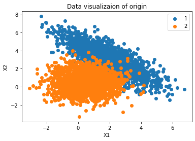

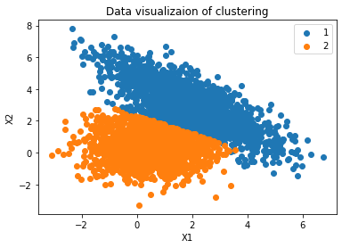

```python
group_sub6 = df_sub6.groupby(by = 'Class')
group_sub6_agglomer = df_sub6.groupby(by = 'agglomer_relabel')

fig = plt.figure()
ax_sub_origin = plt.axes()
for (ele_id,ele) in group_sub6:
  ax_sub_origin.scatter(ele['X1'], ele['X2'], label = ele_id)
ax_sub_origin.set(title = 'Data visualizaion of origin',xlabel = 'X1',ylabel= 'X2')
plt.legend()

fig2 = plt.figure()
ax_sub_clustering = plt.axes()
for (ele_id,ele) in group_sub6_agglomer:
  ax_sub_clustering.scatter(ele['X1'],ele['X2'], label = ele_id)
ax_sub_clustering.set(title = 'Data visualizaion of clustering',xlabel = 'X1',ylabel= 'X2')
plt.legend()

plt.show()
```

# Dealing with Data7

## uploading the data

```python
from google.colab import files
files.upload()
df_sub7 = pd.read_csv(r'Data7.csv').iloc[:,1:]
```

Upload widget is only available when the cell has been executed in the current browser session. Please rerun this cell to enable.

```
Saving Data7.csv to Data7.csv
```

## exploring the data

```python
df_sub7.shape
```

```
(770, 3)
```

```python
df_sub7.head(2)
```

|  | X1 | X2 | Class |
| --- | --- | --- | --- |
| 0 | -3.0 | -3.0 | 5 |
| 1 | -3.0 | 3.0 | 4 |

```python
df_sub7['Class'].value_counts()
```

```
1    395
2    363
5      3
4      3
6      3
3      3
Name: Class, dtype: int64
```

1. k = 6

## kmeans

### clustering process

```python
kmeans_model7 = KMeans(n_clusters = 6, random_state = 20000708)
kmeans_model7.fit(df_sub7.iloc[:,:-1])
df_sub7['kmeans'] = kmeans_model7.labels_
```

### mapping process

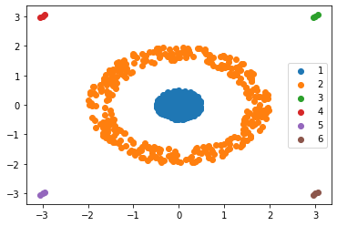

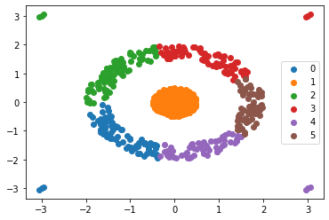

```python
group_sub7 = df_sub7.groupby(by = 'Class')
group_sub7_kmeans = df_sub7.groupby(by = 'kmeans')

fig = plt.figure()
ax_sub_origin = plt.axes()
for (ele_id,ele) in group_sub7:
  ax_sub_origin.scatter(ele['X1'], ele['X2'], label = ele_id)
plt.legend()

fig2 = plt.figure()
ax_sub_clustering = plt.axes()
for (ele_id,ele) in group_sub7_kmeans:
  ax_sub_clustering.scatter(ele['X1'],ele['X2'], label = ele_id)
plt.legend()

plt.show()
```

**According to the map we get manually, we can calculate acc and F1 now!**

```python
mapdict = {0:5,1:1,2:4,3:3,4:6,5:2}
df_sub7['kmeans_relabel'] = df_sub7['kmeans'].map(mapdict)
```

### external validation

```python
print('F1 score of this clustering model is:')
metrics.f1_score(df_sub7['Class'],df_sub7['kmeans_relabel'], average = 'weighted')
```

```
F1 score of this clustering model is:
```

```
0.6684442257297747
```

```python
print('accuracy of this clustering model is:')
metrics.accuracy_score(df_sub7['Class'],df_sub7['kmeans_relabel'])
```

```
accuracy of this clustering model is:
```

```
0.6207792207792208
```

### data visualiztion

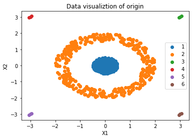

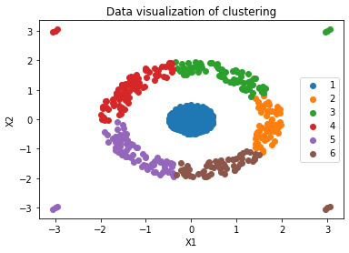

```python
group_sub7 = df_sub7.groupby(by = 'Class')
group_sub7_kmeans = df_sub7.groupby(by = 'kmeans_relabel')

fig = plt.figure()
ax_sub_origin = plt.axes()
for (ele_id,ele) in group_sub7:
  ax_sub_origin.scatter(ele['X1'], ele['X2'], label = ele_id)
ax_sub_origin.set(title = 'Data visualiztion of origin')
ax_sub_origin.set_xlabel('X1')
ax_sub_origin.set_ylabel('X2')
plt.legend()

fig2 = plt.figure()
ax_sub_clustering = plt.axes()
for (ele_id,ele) in group_sub7_kmeans:
  ax_sub_clustering.scatter(ele['X1'],ele['X2'], label = ele_id)
ax_sub_clustering.set(title = 'Data visualization of clustering')
ax_sub_clustering.set_xlabel('X1')
ax_sub_clustering.set_ylabel('X2')
plt.legend()

plt.show()
```

## agglomer

### clustering process

**The output label of agglomerative Clustering changed every time you run the code. Please don't run this cell again**

```python
agglomer_model7 = AgglomerativeClustering(n_clusters = 6)
agglomer_model7.fit(df_sub7.iloc[:,:-1])
df_sub7['agglomer'] = agglomer_model7.labels_
```

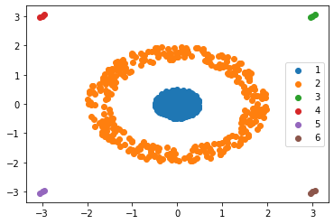

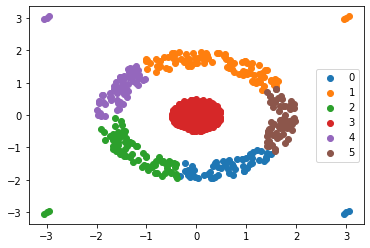

```python
group_sub7 = df_sub7.groupby(by = 'Class')
group_sub7_agglomer = df_sub7.groupby(by = 'agglomer')

fig = plt.figure()
ax_sub_origin = plt.axes()
for (ele_id,ele) in group_sub7:
  ax_sub_origin.scatter(ele['X1'], ele['X2'], label = ele_id)
plt.legend()

fig2 = plt.figure()
ax_sub_clustering = plt.axes()
for (ele_id,ele) in group_sub7_agglomer:
  ax_sub_clustering.scatter(ele['X1'],ele['X2'], label = ele_id)
plt.legend()

plt.show()
```

**According to the map we get manually, we can calculate acc and F1 now!**

```python
mapdict = {0:6,1:3,2:5,3:1,4:4,5:2}
df_sub7['agglomer_relabel'] = df_sub7['agglomer'].map(mapdict)
```

### external validation

```python
print('F1 score of this clustering model is:')
metrics.f1_score(df_sub7['Class'],df_sub7['agglomer_relabel'],average = 'weighted')
```

```
0.6684650985767345
```

```python
print('Accuracy of this clustering model is:')
metrics.accuracy_score(df_sub7['Class'],df_sub7['agglomer_relabel'])
```

```
0.6207792207792208
```

### Data visualiztion

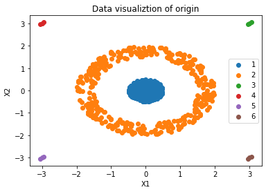

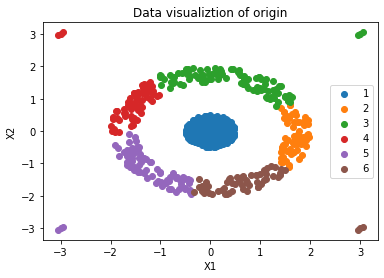

```python
group_sub7 = df_sub7.groupby(by = 'Class')
group_sub7_agglomer = df_sub7.groupby(by = 'agglomer_relabel')

fig = plt.figure()
ax_sub_origin = plt.axes()
for (ele_id,ele) in group_sub7:
  ax_sub_origin.scatter(ele['X1'], ele['X2'], label = ele_id)
ax_sub_origin.set(title = 'Data visualiztion of origin')
ax_sub_origin.set_xlabel('X1')
ax_sub_origin.set_ylabel('X2')
plt.legend()

fig2 = plt.figure()
ax_sub_clustering = plt.axes()
for (ele_id,ele) in group_sub7_agglomer:
  ax_sub_clustering.scatter(ele['X1'],ele['X2'], label = ele_id)
ax_sub_clustering.set(title = 'Data visualiztion of origin')
ax_sub_clustering.set_xlabel('X1')
ax_sub_clustering.set_ylabel('X2')
plt.legend()

plt.show()
```

# Dealing with Data8

## uploading the data

```python
from google.colab import files
files.upload()
```

Upload widget is only available when the cell has been executed in the current browser session. Please rerun this cell to enable.

```
Saving Data8.csv to Data8 (1).csv
```

[output not shown]

```python
df_sub8 = pd.read_csv(r'Data8.csv').iloc[:,1:]
```

## exploring about the data

```python
df_sub8.shape
```

```
(4002, 4)
```

```python
df_sub8.head(2)
```

|  | X1 | X2 | X3 | Class |
| --- | --- | --- | --- | --- |
| 0 | 0.0 | 0.000000 | 1.00000 | 1 |
| 1 | 0.0 | 0.052336 | 0.99863 | 1 |

```python
df_sub8['Class'].value_counts()
```

```
1    4002
Name: Class, dtype: int64
```

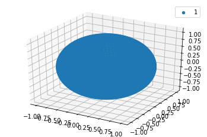

```python
group_sub8 = df_sub8.groupby(by = 'Class')

fig = plt.figure()
ax_sub_origin = plt.axes(projection = '3d')
for (ele_id,ele) in group_sub8:
  ax_sub_origin.scatter3D(ele['X1'], ele['X2'],ele['X3'],label = ele_id)
plt.legend()
```

## It is meaningless to do external validation, which means 'no cluster'(also called n_cluster equal 1).

## kmeans

If we do clustering, metrics decreases. **we'd better make no cluster.**

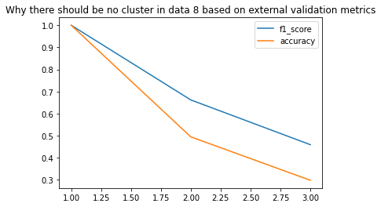

```python
kmeans_model8 = KMeans(n_clusters = 1, random_state = 2170)
kmeans_model8.fit(df_sub8.iloc[:,:-1])
df_sub8['kmeans=1'] = pd.Series(kmeans_model8.labels_).map({0:1})
kmeans_model8 = KMeans(n_clusters = 2, random_state = 2171)
kmeans_model8.fit(df_sub8.iloc[:,:-1])
df_sub8['kmeans=2'] = pd.Series(kmeans_model8.labels_).map({0:1,1:2})
kmeans_model8 = KMeans(n_clusters = 3, random_state = 2172)
kmeans_model8.fit(df_sub8.iloc[:,:-1])
df_sub8['kmeans=3'] = pd.Series(kmeans_model8.labels_).map({0:1,1:2,2:3})

metrics_f1 = []
metrics_accuracy = []
for i in ['kmeans='+str(i) for i in range(1,4)]:
  metrics_f1.append(metrics.f1_score(df_sub8['Class'],df_sub8[i], average = 'weighted'))
  metrics_accuracy.append(metrics.accuracy_score(df_sub8['Class'],df_sub8[i]))

plt.plot(range(1,4),metrics_f1,label = 'f1_score')
plt.plot(range(1,4),metrics_accuracy,label = 'accuracy')
plt.legend()
plt.title('Why there should be no cluster in data 8 based on external validation metrics')
plt.show()
```

## agglomer

**we'd better make no cluster.**

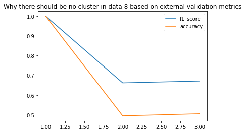

```python
agglomer_model8 = AgglomerativeClustering(n_clusters = 1)
agglomer_model8.fit(df_sub8.iloc[:,:-1])
df_sub8['agglomer=1'] = pd.Series(agglomer_model8.labels_).map({0:1})
agglomer_model8 = AgglomerativeClustering(n_clusters = 2)
agglomer_model8.fit(df_sub8.iloc[:,:-1])
df_sub8['agglomer=2'] = pd.Series(agglomer_model8.labels_).map({0:1,1:2})
agglomer_model8 = AgglomerativeClustering(n_clusters = 3)
agglomer_model8.fit(df_sub8.iloc[:,:-1])
df_sub8['agglomer=3'] = pd.Series(agglomer_model8.labels_).map({0:1,1:2,2:3})

metrics_f1 = []
metrics_accuracy = []
for i in ['agglomer='+str(i) for i in range(1,4)]:
  metrics_f1.append(metrics.f1_score(df_sub8['Class'],df_sub8[i], average = 'weighted'))
  metrics_accuracy.append(metrics.accuracy_score(df_sub8['Class'],df_sub8[i]))

plt.plot(range(1,4),metrics_f1,label = 'f1_score')
plt.plot(range(1,4),metrics_accuracy,label = 'accuracy')
plt.legend()
plt.title('Why there should be no cluster in data 8 based on external validation metrics')
plt.show()
```

## Data visualiztion

**Data before clustering and data after clustering are the same in the plot**

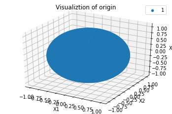

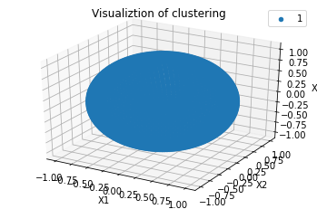

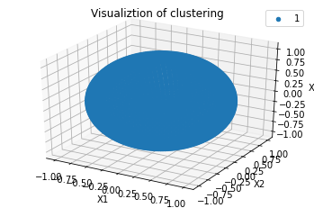

```python
from matplotlib.figure import projections
group_sub8 = df_sub8.groupby(by = 'Class')
group_sub8_kmeans = df_sub8.groupby(by = 'kmeans=1')
group_sub8_agglomer = df_sub8.groupby(by = 'agglomer=1')

fig = plt.figure()
ax_sub_origin = plt.axes(projection = '3d')
for (ele_id,ele) in group_sub8:
  ax_sub_origin.scatter(ele['X1'], ele['X2'],ele['X3'], label = ele_id)
ax_sub_origin.set(title = 'Visualiztion of origin')
ax_sub_origin.set_xlabel('X1')
ax_sub_origin.set_ylabel('X2')
ax_sub_origin.set_zlabel('X3')
plt.legend()

fig2 = plt.figure()
ax_sub_clustering = plt.axes(projection = '3d')
for (ele_id,ele) in group_sub8_agglomer:
  ax_sub_clustering.scatter(ele['X1'],ele['X2'],ele['X3'], label = ele_id)
ax_sub_clustering.set(title = 'Visualiztion of clustering')
ax_sub_clustering.set_xlabel('X1')
ax_sub_clustering.set_ylabel('X2')
ax_sub_clustering.set_zlabel('X3')
plt.legend()

fig3 = plt.figure()
ax_sub_clustering = plt.axes(projection = '3d')
for (ele_id,ele) in group_sub8_agglomer:
  ax_sub_clustering.scatter(ele['X1'],ele['X2'],ele['X3'], label = ele_id)
ax_sub_clustering.set(title = 'Visualiztion of clustering')
ax_sub_clustering.set_xlabel('X1')
ax_sub_clustering.set_ylabel('X2')
ax_sub_clustering.set_zlabel('X3')
plt.legend()

plt.show()
```

```python
!jupyter nbconvert --to html Zeyuan_Liu-IE5374_project_1.ipynb
```